# Concrete Compressive Strength

CTC-34_Lab2: Evolução Gramatical

Matheus Vidal & Pedro Alves

17/11/2019

## Definição da Gramática

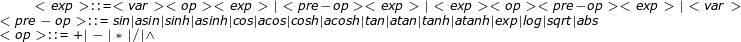

```r
# Limpa Área de trabalho
rm(list = ls())

#set seed
set.seed(165465)

# Não Terminais
V <- c("<exp>","<op>","<var>")

# Terminais
op <- c("+","-","/","*")

# Geração de constantes
max_const <- 3.15
const_quant <- 10000
amostra <- 10000
const <- runif(const_quant,min = 0,max=max_const)

max_const <- 10
const_quant <- 1000
amostra <- 1000
const <- c(const, runif(const_quant,min = max_const/2,max=max_const*1.5))

max_const <- 100
const_quant <- 1000
amostra <- 1000
const <- c(const, runif(const_quant,min = max_const/2,max=max_const*1.5))


max_const <- 1000
const_quant <- 1000
amostra <- 1000
const <- c(const, runif(const_quant,min = max_const/2,max=max_const*1.5))

max_const <- 10000
const_quant <- 1000
amostra <- 1000
const <- c(const, runif(const_quant,min = max_const/2,max=max_const*1.5))

max_const <- 100000
const_quant <- 1000
amostra <- 1000
const <- c(const, runif(const_quant,min = max_const/2,max=max_const*1.5))

max_const <- 1000000
const_quant <- 1000
amostra <- 1000
const <- c(const, runif(const_quant,min = max_const/2,max=max_const*1.5))

max_const <- 10000000
const_quant <- 1000
amostra <- 1000
const <- c(const, runif(const_quant,min = max_const/2,max=max_const*1.5))

max_const <- 100000000
const_quant <- 1000
amostra <- 1000
const <- c(const, runif(const_quant,min = max_const/2,max=max_const*1.5))

var <- rep(c("x","y","z","u","v","w","p","q"),25000)
var <- c(var,const)
sigma <- c(op,var)


# Símbolo Inicial
S <- "<exp>"

# Produções
basicas <- c(rep(c("<var>"),1000),rep(c("<var><op><exp>"),5000),rep(c("<var><op><exp>"),0))
seno <- c(rep(c("sin(<var>)"),35),rep(c("sin(<exp>)"),15),rep(c("sin(<var>)<op><exp>"),20),rep(c("sin(<exp>)<op><exp>"),10))
aseno <- c(rep(c("asin(<var>)"),35),rep(c("asin(<exp>)"),15),rep(c("asin(<var>)<op><exp>"),20),rep(c("asin(<exp>)<op><exp>"),10))
senoh <- c(rep(c("sinh(<var>)"),35),rep(c("sinh(<exp>)"),15),rep(c("sinh(<var>)<op><exp>"),20),rep(c("sinh(<exp>)<op><exp>"),10))
asenoh <- c(rep(c("asinh(<var>)"),35),rep(c("asinh(<exp>)"),15),rep(c("asinh(<var>)<op><exp>"),20),rep(c("asinh(<exp>)<op><exp>"),10))
cosseno <- c(rep(c("cos(<var>)"),35),rep(c("cos(<exp>)"),15),rep(c("cos(<var>)<op><exp>"),20),rep(c("cos(<exp>)<op><exp>"),10))
acosseno <- c(rep(c("acos(<var>)"),35),rep(c("acos(<exp>)"),15),rep(c("acos(<var>)<op><exp>"),20),rep(c("acos(<exp>)<op><exp>"),10))
cossenoh <- c(rep(c("cosh(<var>)"),35),rep(c("cosh(<exp>)"),15),rep(c("cosh(<var>)<op><exp>"),20),rep(c("cosh(<exp>)<op><exp>"),10))
acossenoh <- c(rep(c("acosh(<var>)"),35),rep(c("acosh(<exp>)"),15),rep(c("acosh(<var>)<op><exp>"),20),rep(c("acosh(<exp>)<op><exp>"),10))
tangente <- c(rep(c("tan(<var>)"),35),rep(c("tan(<exp>)"),15),rep(c("tan(<var>)<op><exp>"),20),rep(c("tan(<exp>)<op><exp>"),10))
atangente <- c(rep(c("atan(<var>)"),35),rep(c("atan(<exp>)"),15),rep(c("atan(<var>)<op><exp>"),20),rep(c("atan(<exp>)<op><exp>"),10))
tangenteh <- c(rep(c("tanh(<var>)"),35),rep(c("tanh(<exp>)"),15),rep(c("tanh(<var>)<op><exp>"),20),rep(c("tanh(<exp>)<op><exp>"),10))
atangenteh <- c(rep(c("atanh(<var>)"),35),rep(c("atanh(<exp>)"),15),rep(c("atanh(<var>)<op><exp>"),20),rep(c("atanh(<exp>)<op><exp>"),10))
logaritmo <- rep(c(rep(c("log(<var>)"),35),rep(c("log(<exp>)"),15),rep(c("log(<var>)<op><exp>"),20),rep(c("log(<exp>)<op><exp>"),10)),5)
exp_natural <- rep(c(rep(c("exp(<var>)"),35),rep(c("exp(<exp>)"),15),rep(c("exp(<var>)<op><exp>"),20),rep(c("exp(<exp>)<op><exp>"),10)),5)
exponencial <- rep(c(rep(c("<exp>^(<var>)"),35),rep(c("<exp>^(<exp>)"),15),rep(c("<exp>^(<var>)<op><exp>"),20),rep(c("<exp>^(<exp>)<op><exp>"),10)),2)
modulo <- rep(c(rep(c("abs(<var>)"),35),rep(c("abs(<exp>)"),15),rep(c("abs(<var>)<op><exp>"),20),rep(c("abs(<exp>)<op><exp>"),10)),2)
quadrada <- rep(c(rep(c("sqrt(<var>)"),35),rep(c("sqrt(<exp>)"),15),rep(c("sqrt(<var>)<op><exp>"),20),rep(c("sqrt(<exp>)<op><exp>"),10)),5)

#P <- list(c(basicas,seno,exp_natural,quadrada),op,var)

P <- list(c(basicas,quadrada,seno,aseno,asenoh,cosseno,cossenoh,acosseno,senoh,cossenoh,logaritmo,tangente,atangenteh,atangente,tangenteh,
            exp_natural,exponencial,modulo),op,var)
```

## Definição dos Cromossomos

Cada cromossomo é gerado aleatóriamente.

```r
cromo_size <- 200
cromo_quant <- 100
max_gene <- 10000000
p.mutacao <- c(0,0,0.01,0.03,0.05,0.1,0.2,0.35,0.55,0.80,1,1,1)
p.cruzamento <- 0.4
if(max_gene < cromo_size*cromo_quant){
  max_gene <- cromo_size*cromo_quant
}
first_sorteados_fraction <- 10
order_size_fraction <- 3
prop_filhos <- 2
C <- matrix(sample(max_gene,max_gene),cromo_quant,cromo_size) # Ci = C[i,]

# Adicionando o melhor cromossomo da geração passada
cbom <- read.csv(file="cbom.csv", header=TRUE)
cbom <- cbom[1:dim(cbom)[1],]
C[1,] <- cbom
```

## Carregamento dos Dados de Treinamento

```r
trainingData <- read.csv(file="training.csv", header=TRUE, sep=",")
```

## Gerando Derivação

Gera-se aqui as expressões matemáticas a partir de cada cromossomo.

```r
S <- "<exp>"
derivacao <- rep(S,cromo_quant) # símbolo inicial
endCromo <- array(0,cromo_quant)
for (i in 1:cromo_quant) {
  S <- "<exp>"
  j <- 0
  count <- 0
  while (S!="<NA>"){
    count <- count + 1
    # evitar loop infinito, para cromossomos mal escolhidos:
    if (count > cromo_size){
      tmp <- stringr::str_match(derivacao[i], ".*?<")
      tmp <- substr(tmp,1,nchar(tmp)-1)
      if (is.na(tmp)){
        last.char <- substr(tmp,nchar(derivacao[i]),nchar(derivacao[i]))
        if (!last.char%in%var){
          tmp <- substr(derivacao[i],1,nchar(derivacao[i])-1)
        }
      } else {
        last.char <- substr(tmp,nchar(tmp),nchar(tmp))
        while (!last.char%in%var){
          # se terminar em operador
          if (last.char%in%op){
            tmp <- substr(tmp,1,nchar(tmp)-1)
          } else if (substr(tmp,nchar(tmp)-1,nchar(tmp))=="^("){
            tmp <- substr(tmp,1,nchar(tmp)-2)
          } else if (substr(tmp,nchar(tmp)-5,nchar(tmp))=="asinh("){
            tmp <- substr(tmp,1,nchar(tmp)-6)
          }  else if (substr(tmp,nchar(tmp)-5,nchar(tmp))=="acosh("){
            tmp <- substr(tmp,1,nchar(tmp)-6)
          }  else if (substr(tmp,nchar(tmp)-5,nchar(tmp))=="atanh("){
             tmp <- substr(tmp,1,nchar(tmp)-6)
          } else if (substr(tmp,nchar(tmp)-1,nchar(tmp))=="h("){
            tmp <- substr(tmp,1,nchar(tmp)-5)
          } else if (substr(tmp,nchar(tmp)-4,nchar(tmp))=="sqrt("){
            tmp <- substr(tmp,1,nchar(tmp)-5)
          } else if (substr(tmp,nchar(tmp)-4,nchar(tmp))=="asin("){
            tmp <- substr(tmp,1,nchar(tmp)-5)
          }  else if (substr(tmp,nchar(tmp)-4,nchar(tmp))=="acos("){
            tmp <- substr(tmp,1,nchar(tmp)-5)
          }  else if (substr(tmp,nchar(tmp)-4,nchar(tmp))=="atan("){
             tmp <- substr(tmp,1,nchar(tmp)-5)
          } else if (last.char=="("){
            tmp <- substr(tmp,1,nchar(tmp)-4)
          }
          last.char <- substr(tmp,nchar(tmp),nchar(tmp))
        }
        endCromo[i] <- -1
      }
      # colocar parênteses restantes
      abrindo <- stringr::str_count(tmp,"\\(")
      fechando <- stringr::str_count(tmp,"\\)")
      add <- strrep(")",abrindo-fechando)
      tmp <- paste(tmp,add,sep = "")

      derivacao[i] <- tmp
      S <- "<NA>"
    }
    j <- j%%cromo_size + 1

    # Faz substituições
    if (S=="<exp>"){
      rule <- P[[1]][1+C[i,j]%%length(P[[1]])] # determina a regra a ser aplicada
      derivacao[i] <- sub(S, rule, derivacao[i]) # atualiza derivacao por substituição
      S <- stringr::str_match(derivacao[i], "<(.*?)>") # acha o primeiro <..>
      S <- paste("<",S[,2],">",sep = "") # novo simbolo
    } else if (S=="<op>"){
      rule <- P[[2]][1+C[i,j]%%length(P[[2]])] # determina a regra a ser aplicada
      derivacao[i] <- sub(S, rule, derivacao[i]) # atualiza derivacao por substituição
      S <- stringr::str_match(derivacao[i], "<(.*?)>") # acha o primeiro <..>
      S <- paste("<",S[,2],">",sep = "") # novo simbolo
    } else if (S=="<var>"){
      rule <- P[[3]][1+C[i,j]%%length(P[[3]])] # determina a regra a ser aplicada
      derivacao[i] <- sub(S, rule, derivacao[i]) # atualiza derivacao por substituição
      S <- stringr::str_match(derivacao[i], "<(.*?)>") # acha o primeiro <..>
      S <- paste("<",S[,2],">",sep = "") # novo simbolo
    }
  }
  endCromo[i] <- endCromo[i] + count
}
derivacao
```

```
##   [1] "tanh(x)*sqrt(v)+sqrt(sin(q))/cosh(q)"
##   [2] "sqrt(exp(v+p+cosh(p))-p-v/x-w+cosh(v))"
##   [3] "u+2.23955080801388/asinh(x)"
##   [4] "x"
##   [5] "y-v"
##   [6] "p*p+sqrt(z)"
##   [7] "sqrt(w)+w"
##   [8] "u/sqrt(asinh(z))-u-98.3543772716075*exp(y)^(v)-atanh(q)/sqrt(q)-y-q-q-exp(abs(q))"
##   [9] "y^(x-y/2.16979381801793-sinh(v)+x/w/y/u*p)/exp(y)"
##  [10] "y/q-u"
##  [11] "u*exp(z)-z+exp(y)"
##  [12] "u+p"
##  [13] "z+z-z*w*exp(2.41571084397146)"
##  [14] "x/u-exp(w)"
##  [15] "z+u*x/asin(x)"
```

[output cut: 85 more lines]

## Avaliação dos Cromossomos

Avalia quão bem estão cada cromossomo pelo seus respectivos valores de erro quadrático médio.

```r
options(warn = -1)
training.model <- trainingData[,c("strength")]
erroQuadraticoMedio <- rep(Inf,cromo_quant)
for (k in 1:cromo_quant){
  training.data <- c()
  for (i in 1:length(training.model)){
    x <- trainingData[i,2]
    y <- trainingData[i,3]
    z <- trainingData[i,4]
    u <- trainingData[i,5]
    v <- trainingData[i,6]
    w <- trainingData[i,7]
    p <- trainingData[i,8]
    q <- trainingData[i,9]
    valor <- suppressWarnings(eval(parse(text=derivacao[k])))
    training.data <- c(training.data,valor)
  }
  erroQuadraticoMedio[k] <- mean((training.data - (training.model))^2)
}
options(warn = 0)
erroQuadraticoMedio
```

```
##   [1]   0.01622554          NaN          Inf   0.05154777   0.36266019
##   [6]   0.29813175   0.83324259          Inf          NaN 623.93697007
##  [11]   1.69902933   0.36500144   5.65134265          Inf          NaN
##  [16]          Inf   0.10277478          NaN   3.97007001          NaN
##  [21]   0.11765367   0.10277478          NaN   1.60354680   0.13635021
##  [26]   0.14383323   0.18190592          NaN   0.37455799          NaN
##  [31]          NaN   0.26940546          Inf   0.43500996   3.01277710
##  [36]   0.09182322   0.06490272          Inf   0.10605711          NaN
##  [41]   0.77641610          NaN          Inf   0.10827206   0.37231403
##  [46]   0.40556086   1.55139642   0.12650189          NaN  67.75983461
##  [51]   1.29956003   0.22137168          NaN   0.21289813   0.37455799
##  [56]          Inf          NaN   0.06490272   0.87816969   0.11911191
##  [61]          NaN          NaN   0.40938331          NaN   3.29452480
##  [66]   2.83271027   0.14935169   0.56393354   0.17395544   0.18240757
##  [71]          Inf          Inf          Inf          NaN   0.14935169
##  [76]          NaN          Inf          NaN   0.74977703   0.11911191
##  [81]   0.11138038          Inf          NaN   1.75402404   0.05154777
##  [86]          NaN   0.05154777          NaN   1.71985668          NaN
##  [91]   0.40833916          NaN   0.73216680   1.41108091   0.22183285
##  [96]          NaN   0.06416851   0.30952445          Inf          NaN
```

## Cromossomo Vencedor da Primeira Geração

```r
# Cromossomo vencedor:
vencedor <- which.min(erroQuadraticoMedio)
vencedor
```

```
## [1] 1
```

```r
raizErroQuadraticoMedioMin <- sqrt(erroQuadraticoMedio[vencedor])
derivacao_vencedora <-derivacao[vencedor]
raizErroQuadraticoMedioMin
```

```
## [1] 0.1273795
```

```r
derivacao_vencedora
```

```
## [1] "tanh(x)*sqrt(v)+sqrt(sin(q))/cosh(q)"
```

## Método de Geração da Nova População

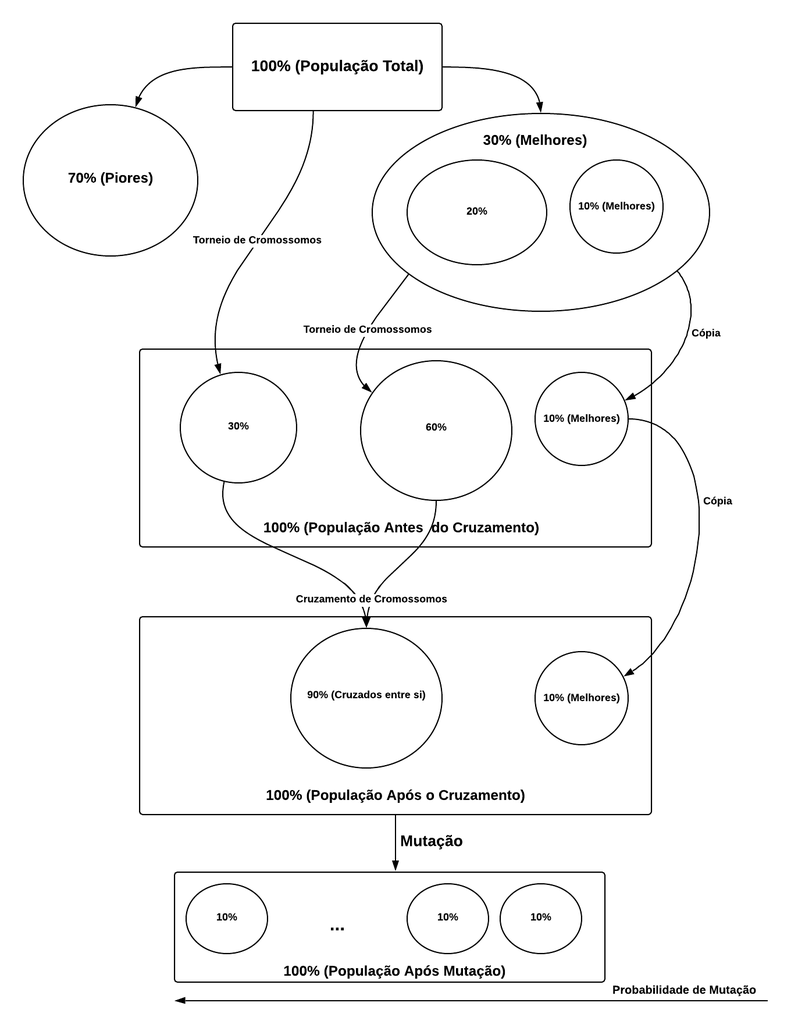

## Torneio de Cromossomos

Do algoritmo genético, é feito o torneio de cromossomos, de modo a escolher o de melhor erro quadrático médio a cada disputa entre dois deles. No torneio de cromossomos, nós queremos uma variabilidade alta e um bom controle de qualidade, logo, selecionamos os cromossomos de derivações diferentes e com erro quadrático diferente de infinito, a partir manteremos os 10% melhores para a próxima geração, e todos irão participar de um torneio para serem cruzados e mutados.

```r
sorteados <- c()
invalidosNanInf <- which(erroQuadraticoMedio %in% c(NaN,Inf))
invalidosVazio <- which(derivacao %in% c(""))
invalidos <- c(invalidosNanInf,invalidosVazio,which(duplicated(derivacao)))
validos <-c(1:length(derivacao))[which(!c(1:length(derivacao)) %in% invalidos)]

first_sorteados <- length(validos)%/%first_sorteados_fraction
order_size <- (order_size_fraction*length(validos))%/%first_sorteados_fraction
ordenados <- validos[order(erroQuadraticoMedio[validos])][1:order_size]
sorteados <- validos[order(erroQuadraticoMedio[validos])][1:first_sorteados]

for (i in (first_sorteados+1):(order_size*prop_filhos+first_sorteados+1)){
  sorteio <- rep(NA,cromo_quant)
  pos <- sample(ordenados,2) # sorteio dois crommossomos
  sorteio[pos] <- pos
  sorteados <- c(sorteados,which.min(erroQuadraticoMedio[sorteio]))
}

for (i in (order_size*prop_filhos+first_sorteados+2):cromo_quant){
  sorteio <- rep(NA,cromo_quant)
  pos <- sample(validos,2) # sorteio dois crommossomos
  sorteio[pos] <- pos
  sorteados <- c(sorteados,which.min(erroQuadraticoMedio[sorteio]))
}

C <- C[sorteados,]
endCromo <- endCromo[sorteados]

sorteados
```

```
##   [1]  1  4 97 37 36 37  4 48 97  1 37 26 37  1  4 97 39 39  1 39 36 25  4 21 36
##  [26] 97 48 39 81  4 97  4 21 97 25 44 66 60 12 54  4 26 91 46 46 52 63 48 41 29
##  [51]  5 69 52 68  6 25 81 26 44 81 93 39 48 63 60 70 12 39 79 21 21 26 39  4 34
##  [76] 70 81 24  6 36 59 17 67 48 29 39 91 97 59 59 17 81 54 55 26 67 26 32 37 67
```

## Cruzamento de Cromossomos

Conforme o algoritmo genético, os cromossomos que vencedores de cada disputa são cruzados em pares. No cruzamento, nós pegamos o pivô sempre tendo que estar no intervalo dos genes usados pela derivação, assim faz com que o cruzamento altere a derivação, logo o resultado.

```r
i <- (first_sorteados+1)
while (i < length(sorteados)){
  # avalia a possibilidade de cruzamento de cada par
  vai.cruzar <- runif(1)
  if (vai.cruzar<=p.cruzamento){ # realiza cruzamento
    pto.cruza <- endCromo[i]
    if(pto.cruza > endCromo[i+1])
    {
      pto.cruza <- endCromo[i+1]
    }
    pto.cruza <- sample(pto.cruza-1,1)
    index_pai <- i
    index_mae <- i+1
    tmp <- C[index_pai,(pto.cruza+1):cromo_size]
    C[index_pai,(pto.cruza+1):cromo_size] <- C[index_mae,(pto.cruza+1):cromo_size]
    C[index_mae,(pto.cruza+1):cromo_size] <- tmp
  }
  i <- i+2 # pula o proximo cromossomo (estamos olhando os pares)
}
```

## Mutação

Aqui, verifica-se a possibilidade de mutação de qualquer gene de qualquer cromossomo. A mutação não ocorre nos 10% melhores diretamente, mas nas suas copias feitas através do vetor de cromossomos, e ao passar um bloco conjunto de 10% dos cromossomos, onde o primeiro é composto pelos melhores a probabilidade de mudar cada gene irá aumentar, garantindo que os melhores passem por mutações pequenas e grandes.

```r
vai.mutar <- matrix(runif(cromo_quant*cromo_size),cromo_quant,cromo_size)
divisa_prob <- cromo_quant%/%first_sorteados_fraction
for (i in (first_sorteados+1):cromo_quant){
  linhaMutar <- vai.mutar[i,]
  prob<-p.mutacao[i%/%divisa_prob+1]
  if(prob*endCromo[i]<0.3)
  {
    prob <- 0.3/endCromo[i]
  }
  id <- which(linhaMutar < prob)
  for (j in 1:length(id)){
    coluna <- id[j]
    C[i,coluna] <- sample(max_gene,1)
  }
}
```

## Comparando com o Próprio training.csv (fit)

Aqui vamos comparar o quão bem nosso cromossomo vencedor se adequa ao dataset de treinamento.

```r
fit.data <- c()
for (i in 1:dim(trainingData)[1]){
  x <- trainingData[i,2]
  y <- trainingData[i,3]
  z <- trainingData[i,4]
  u <- trainingData[i,5]
  v <- trainingData[i,6]
  w <- trainingData[i,7]
  p <- trainingData[i,8]
  q <- trainingData[i,9]
  fit.data <- c(fit.data,eval(parse(text=derivacao_vencedora)))
}
```

Graficamente, os dados calculados pelo cromossomo vencedor devem estar próximos da reta, como visto a seguir:

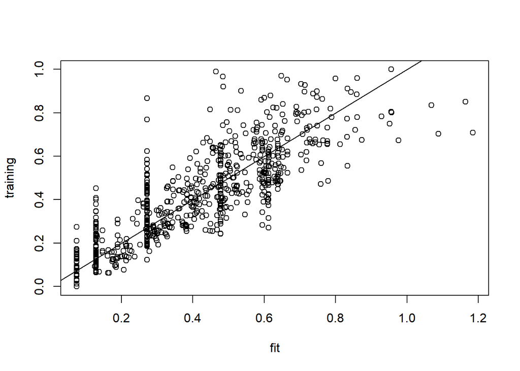

```r
 plot(fit.data,training.model,
      xlab="fit",ylab="training")
 abline(a=0,b=1)
```

## Após N Gerações

Vamos repetir o processo acima para mais N gerações.

```r
ngeracoes <- 0 # Contador de Gerações do 0
```

```r
N <- 50 # número de gerações
ngeracoes <- ngeracoes + N
for (g in 1:N){
  ## Gerando Derivação
  if(g%%5 == 0){
    cat("Geração: ", g,"\n")
  }
  S <- "<exp>"
  derivacao <- rep(S,cromo_quant) # símbolo inicial
  endCromo <- array(0,cromo_quant)
  for (i in 1:cromo_quant) {
    S <- "<exp>"
    j <- 0
    count <- 0
    while (S!="<NA>"){
      count <- count + 1
      # evitar loop infinito, para cromossomos mal escolhidos:
      if (count > cromo_size){
        tmp <- stringr::str_match(derivacao[i], ".*?<")
        tmp <- substr(tmp,1,nchar(tmp)-1)
        if (is.na(tmp)){
          last.char <- substr(tmp,nchar(derivacao[i]),nchar(derivacao[i]))
          if (!last.char%in%var){
            tmp <- substr(derivacao[i],1,nchar(derivacao[i])-1)
          }
        } else {
        last.char <- substr(tmp,nchar(tmp),nchar(tmp))
        while (!last.char%in%var){
          # se terminar em operador
          if (last.char%in%op){
            tmp <- substr(tmp,1,nchar(tmp)-1)
          } else if (substr(tmp,nchar(tmp)-1,nchar(tmp))=="^("){
            tmp <- substr(tmp,1,nchar(tmp)-2)
          } else if (substr(tmp,nchar(tmp)-5,nchar(tmp))=="asinh("){
            tmp <- substr(tmp,1,nchar(tmp)-6)
          }  else if (substr(tmp,nchar(tmp)-5,nchar(tmp))=="acosh("){
            tmp <- substr(tmp,1,nchar(tmp)-6)
          }  else if (substr(tmp,nchar(tmp)-5,nchar(tmp))=="atanh("){
             tmp <- substr(tmp,1,nchar(tmp)-6)
          } else if (substr(tmp,nchar(tmp)-1,nchar(tmp))=="h("){
            tmp <- substr(tmp,1,nchar(tmp)-5)
          } else if (substr(tmp,nchar(tmp)-4,nchar(tmp))=="sqrt("){
            tmp <- substr(tmp,1,nchar(tmp)-5)
          } else if (substr(tmp,nchar(tmp)-4,nchar(tmp))=="asin("){
            tmp <- substr(tmp,1,nchar(tmp)-5)
          }  else if (substr(tmp,nchar(tmp)-4,nchar(tmp))=="acos("){
            tmp <- substr(tmp,1,nchar(tmp)-5)
          }  else if (substr(tmp,nchar(tmp)-4,nchar(tmp))=="atan("){
             tmp <- substr(tmp,1,nchar(tmp)-5)
          } else if (last.char=="("){
            tmp <- substr(tmp,1,nchar(tmp)-4)
          }
          last.char <- substr(tmp,nchar(tmp),nchar(tmp))
        }
        endCromo[i] <- -1
      }
        # colocar parênteses restantes
        abrindo <- stringr::str_count(tmp,"\\(")
        fechando <- stringr::str_count(tmp,"\\)")
        add <- strrep(")",abrindo-fechando)
        tmp <- paste(tmp,add,sep = "")

        derivacao[i] <- tmp
        S <- "<NA>"
      }
      j <- j%%cromo_size + 1
      if (S=="<exp>"){
        rule <- P[[1]][1+C[i,j]%%length(P[[1]])] # determina a regra a ser aplicada
        derivacao[i] <- sub(S, rule, derivacao[i]) # atualiza derivacao por substituição
        S <- stringr::str_match(derivacao[i], "<(.*?)>") # acha o primeiro <..>
        S <- paste("<",S[,2],">",sep = "") # novo símbolo
      } else if (S=="<op>"){
        rule <- P[[2]][1+C[i,j]%%length(P[[2]])] # determina a regra a ser aplicada
        derivacao[i] <- sub(S, rule, derivacao[i]) # atualiza derivacao por substituição
        S <- stringr::str_match(derivacao[i], "<(.*?)>") # acha o primeiro <..>
        S <- paste("<",S[,2],">",sep = "") # novo símbolo
      } else if (S=="<var>"){
        rule <- P[[3]][1+C[i,j]%%length(P[[3]])] # determina a regra a ser aplicada
        derivacao[i] <- sub(S, rule, derivacao[i]) # atualiza derivacao por substituição
        S <- stringr::str_match(derivacao[i], "<(.*?)>") # acha o primeiro <..>
        S <- paste("<",S[,2],">",sep = "") # novo símbolo
      }
    }
    endCromo[i] <- endCromo[i] + count
  }


  ## Avaliação dos Cromossomos

  training.model <- trainingData[,c("strength")]
  erroQuadraticoMedio <- rep(0,cromo_quant)
  for (k in 1:cromo_quant){
    training.data <- c()
    for (i in 1:length(training.model)){
      x <- trainingData[i,2]
      y <- trainingData[i,3]
      z <- trainingData[i,4]
      u <- trainingData[i,5]
      v <- trainingData[i,6]
      w <- trainingData[i,7]
      p <- trainingData[i,8]
      q <- trainingData[i,9]
      valor <- suppressWarnings(eval(parse(text=derivacao[k])))
      training.data <- c(training.data,valor)
    }
    erroQuadraticoMedio[k] <- mean((training.data - (training.model))^2)
  }

  ## Torneio de Cromossomos

  sorteados <- c()
  invalidosNanInf <- which(erroQuadraticoMedio %in% c(NaN,Inf))
  invalidosVazio <- which(derivacao %in% c(""))
  invalidos <- c(invalidosNanInf,invalidosVazio,which(duplicated(derivacao)))
  validos <-c(1:length(derivacao))[which(!c(1:length(derivacao)) %in% invalidos)]

  first_sorteados <- length(validos)%/%first_sorteados_fraction
  order_size <- (order_size_fraction*length(validos))%/%first_sorteados_fraction
  ordenados <- validos[order(erroQuadraticoMedio[validos])][1:order_size]
  sorteados <- validos[order(erroQuadraticoMedio[validos])][1:first_sorteados]

  if(length(sorteados)>0)
  {
    if(sqrt(erroQuadraticoMedio[sorteados[1]])<raizErroQuadraticoMedioMin)
    {
      raizErroQuadraticoMedioMin<-sqrt(erroQuadraticoMedio[sorteados[1]])
      cromossomo_vencedor <- C[sorteados[1],]
      derivacao_vencedora <- derivacao[sorteados[1]]
      cat("Achou pto de mínimo: ",raizErroQuadraticoMedioMin," com derivação: ",derivacao_vencedora,"\n")
    }
  }


  for (i in (first_sorteados+1):(order_size*prop_filhos+first_sorteados+1)){
    sorteio <- rep(NA,cromo_quant)
    pos <- sample(ordenados,2) # sorteio dois crommossomos
    sorteio[pos] <- pos
    sorteados <- c(sorteados,which.min(erroQuadraticoMedio[sorteio]))
  }

  for (i in (order_size*prop_filhos+first_sorteados+2):cromo_quant){
    sorteio <- rep(NA,cromo_quant)
    pos <- sample(validos,2) # sorteio dois crommossomos
    sorteio[pos] <- pos
    sorteados <- c(sorteados,which.min(erroQuadraticoMedio[sorteio]))
  }
  C <- C[sorteados,]

  ## Cruzamento de Cromossomos

  i <- (first_sorteados+1)
  while (i < length(sorteados)){
    # avalia a possibilidade de cruzamento de cada par
    vai.cruzar <- runif(1)
    if (vai.cruzar<=p.cruzamento){ # realiza cruzamento
      pto.cruza <- endCromo[i]
      if(pto.cruza > endCromo[i+1])
      {
        pto.cruza <- endCromo[i+1]
      }
      pto.cruza <- sample(pto.cruza-1,1)
      index_pai <- i
      index_mae <- i+1
      tmp <- C[index_pai,(pto.cruza+1):cromo_size]
      C[index_pai,(pto.cruza+1):cromo_size] <- C[index_mae,(pto.cruza+1):cromo_size]
      C[index_mae,(pto.cruza+1):cromo_size] <- tmp
    }
    i <- i+2 # pula o próximo cromossomo (estamos olhando os pares)
  }

  ## Mutação

  vai.mutar <- matrix(runif(cromo_quant*cromo_size),cromo_quant,cromo_size)
  divisa_prob <- cromo_quant%/%first_sorteados_fraction
  for (i in (first_sorteados+1):cromo_quant){
    linhaMutar <- vai.mutar[i,]
    prob<-p.mutacao[i%/%divisa_prob+1]
    if(prob*endCromo[i]<0.3)
    {
      prob <- 0.3/endCromo[i]
    }
    id <- which(linhaMutar < prob)
    for (j in 1:length(id)){
      coluna <- id[j]
      C[i,coluna] <- sample(max_gene,1)
    }
  }

}
```

```
## Geração:  5
## Geração:  10
## Geração:  15
## Geração:  20
## Geração:  25
## Geração:  30
## Geração:  35
## Achou pto de mínimo:  0.1264643  com derivação:  tanh(x)*sqrt(v)+sqrt(tanh(q))/cosh(q)
## Geração:  40
## Geração:  45
## Geração:  50
```

```r
## Encontra as Últimas Derivações

## Gerando Derivação
S <- "<exp>"
derivacao <- rep(S,cromo_quant) # símbolo inicial
endCromo <- array(0,cromo_quant)
for (i in 1:cromo_quant) {
  S <- "<exp>"
  j <- 0
  count <- 0
  while (S!="<NA>"){
    count <- count + 1
    # evitar loop infinito, para cromossomos mal escolhidos:
    if (count > cromo_size){
      tmp <- stringr::str_match(derivacao[i], ".*?<")
      tmp <- substr(tmp,1,nchar(tmp)-1)
      if (is.na(tmp)){
        last.char <- substr(tmp,nchar(derivacao[i]),nchar(derivacao[i]))
        if (!last.char%in%var){
          tmp <- substr(derivacao[i],1,nchar(derivacao[i])-1)
        }
      } else {
        last.char <- substr(tmp,nchar(tmp),nchar(tmp))
        while (!last.char%in%var){
          # se terminar em operador
          if (last.char%in%op){
            tmp <- substr(tmp,1,nchar(tmp)-1)
          } else if (substr(tmp,nchar(tmp)-1,nchar(tmp))=="^("){
            tmp <- substr(tmp,1,nchar(tmp)-2)
          } else if (substr(tmp,nchar(tmp)-5,nchar(tmp))=="asinh("){
            tmp <- substr(tmp,1,nchar(tmp)-6)
          }  else if (substr(tmp,nchar(tmp)-5,nchar(tmp))=="acosh("){
            tmp <- substr(tmp,1,nchar(tmp)-6)
          }  else if (substr(tmp,nchar(tmp)-5,nchar(tmp))=="atanh("){
             tmp <- substr(tmp,1,nchar(tmp)-6)
          } else if (substr(tmp,nchar(tmp)-1,nchar(tmp))=="h("){
            tmp <- substr(tmp,1,nchar(tmp)-5)
          } else if (substr(tmp,nchar(tmp)-4,nchar(tmp))=="sqrt("){
            tmp <- substr(tmp,1,nchar(tmp)-5)
          } else if (substr(tmp,nchar(tmp)-4,nchar(tmp))=="asin("){
            tmp <- substr(tmp,1,nchar(tmp)-5)
          }  else if (substr(tmp,nchar(tmp)-4,nchar(tmp))=="acos("){
            tmp <- substr(tmp,1,nchar(tmp)-5)
          }  else if (substr(tmp,nchar(tmp)-4,nchar(tmp))=="atan("){
             tmp <- substr(tmp,1,nchar(tmp)-5)
          } else if (last.char=="("){
            tmp <- substr(tmp,1,nchar(tmp)-4)
          }
          last.char <- substr(tmp,nchar(tmp),nchar(tmp))
        }
      }
      # colocar parênteses restantes
      abrindo <- stringr::str_count(tmp,"\\(")
      fechando <- stringr::str_count(tmp,"\\)")
      add <- strrep(")",abrindo-fechando)
      tmp <- paste(tmp,add,sep = "")

      derivacao[i] <- tmp
      S <- "<NA>"
    }
    j <- j%%cromo_size + 1
    if (S=="<exp>"){
      rule <- P[[1]][1+C[i,j]%%length(P[[1]])] # determina a regra a ser aplicada
      derivacao[i] <- sub(S, rule, derivacao[i]) # atualiza derivacao por substituição
      S <- stringr::str_match(derivacao[i], "<(.*?)>") # acha o primeiro <..>
      S <- paste("<",S[,2],">",sep = "") # novo símbolo
    } else if (S=="<op>"){
      rule <- P[[2]][1+C[i,j]%%length(P[[2]])] # determina a regra a ser aplicada
      derivacao[i] <- sub(S, rule, derivacao[i]) # atualiza derivacao por substituição
      S <- stringr::str_match(derivacao[i], "<(.*?)>") # acha o primeiro <..>
      S <- paste("<",S[,2],">",sep = "") # novo símbolo
    } else if (S=="<var>"){
      rule <- P[[3]][1+C[i,j]%%length(P[[3]])] # determina a regra a ser aplicada
      derivacao[i] <- sub(S, rule, derivacao[i]) # atualiza derivacao por substituição
      S <- stringr::str_match(derivacao[i], "<(.*?)>") # acha o primeiro <..>
      S <- paste("<",S[,2],">",sep = "") # novo símbolo
    }
  }
  endCromo[i] <- endCromo[i] + count
}
```

## Escolha do Cromossomo Vencedor

Escolhemos o melhor cromossomo, *i.e.*, o de menor erro quadrático médio.

```r
training.model <- trainingData[,c("strength")]
erroQuadraticoMedio <- rep(0,cromo_quant)
for (k in 1:cromo_quant){
  training.data <- c()
  for (i in 1:length(training.model)){
    x <- trainingData[i,2]
    y <- trainingData[i,3]
    z <- trainingData[i,4]
    u <- trainingData[i,5]
    v <- trainingData[i,6]
    w <- trainingData[i,7]
    p <- trainingData[i,8]
    q <- trainingData[i,9]
    valor <- suppressWarnings(eval(parse(text=derivacao[k])))
    training.data <- c(training.data,valor)
  }
  erroQuadraticoMedio[k] <- mean((training.data - (training.model))^2)
}

# Cromossomo vencedor:
vencedor <- which.min(erroQuadraticoMedio)
erroQuadraticoMedio
```

```
##   [1] 0.01599321 0.01603182 0.01622554 0.01670511 0.01738566 0.02822475
##   [7] 0.01670511        NaN        NaN 0.42002546 0.01599321 0.01835666
##  [13] 0.01599321 0.01738566 0.01670511 0.15827247        NaN 0.02551287
##  [19] 0.01831774 0.01856699 0.01856699 0.01856699 0.07851385 0.01670511
##  [25] 0.02270169 0.02259699 0.01622554 0.11470247 0.01831774 0.01795679
##  [31] 0.11042661 0.01795679 0.09689052 0.01603182 0.01603182 0.01831774
##  [37] 0.05154777 0.10887255 0.01599321 0.15827247 1.52395052 0.01856699
##  [43] 1.76598037        NaN 0.03122675 0.34397860 0.02027594 0.01599321
##  [49] 0.05154777 0.28711764 0.05154777 0.07284153 0.44891851        NaN
##  [55] 1.33842357 0.12184025 0.12823683 0.04561379 0.65160368 0.02333729
##  [61]        NaN        NaN 0.42551784 0.15039801 0.14706017 0.01670511
##  [67]        NaN 0.05341901        NaN        NaN        Inf        NaN
##  [73]        NaN 0.19248044 0.09125717 0.36500144 0.07284153 6.59513655
##  [79] 2.02658083        NaN 0.33790788        NaN        NaN        NaN
##  [85] 0.05154777        Inf        NaN        Inf 0.40842256 0.22189871
##  [91] 0.07974003        Inf 0.24121915        NaN        NaN 0.15449584
##  [97] 0.04561379 0.05154777        Inf 0.30358094
```

```r
vencedor
```

```
## [1] 1
```

```r
derivacao_vencedora <- derivacao[vencedor]
raizErroQuadraticoMedioMin <- sqrt(erroQuadraticoMedio[vencedor])
raizErroQuadraticoMedioMin
```

```
## [1] 0.1264643
```

```r
derivacao_vencedora
```

```
## [1] "tanh(x)*sqrt(v)+sqrt(tanh(q))/cosh(q)"
```

## Comparando com o Próprio training.csv (fit)

Novamente, aqui vamos comparar o quão bem nosso cromossomo vencedor se adequa ao dataset de treinamento.

```r
fit.data <- c()
for (i in 1:dim(trainingData)[1]){
  x <- trainingData[i,2]
  y <- trainingData[i,3]
  z <- trainingData[i,4]
  u <- trainingData[i,5]
  v <- trainingData[i,6]
  w <- trainingData[i,7]
  p <- trainingData[i,8]
  q <- trainingData[i,9]
  fit.data <- c(fit.data,eval(parse(text=derivacao_vencedora)))
}
```

Graficamente, os dados calculados pelo cromossomo vencedor devem estar próximos da reta, como visto a seguir:

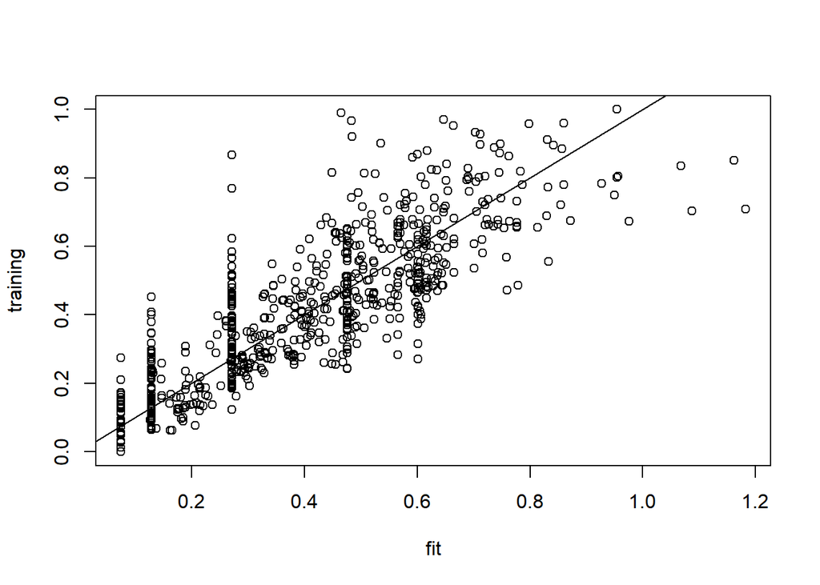

```r
 plot(fit.data,training.model,
      xlab="fit",ylab="training")
 abline(a=0,b=1)
```

## Carregamento dos Dados de Teste

```r
testingData <- read.csv(file="testing.csv", header=TRUE, sep=",")
```

## Predição de Dados

Vamos aplicar o cromossomo vencedor para predizer o dado de saída a partir de entradas advindas de *testing.csv*.

```r
predict.data <- c()
for (i in 1:dim(testingData)[1]){
  x <- testingData[i,2]
  y <- testingData[i,3]
  z <- testingData[i,4]
  u <- testingData[i,5]
  v <- testingData[i,6]
  w <- testingData[i,7]
  p <- testingData[i,8]
  q <- testingData[i,9]
  predict.data <- c(predict.data,eval(parse(text=derivacao_vencedora)))
}
```

Graficamente, os dados preditos são observados a seguir:

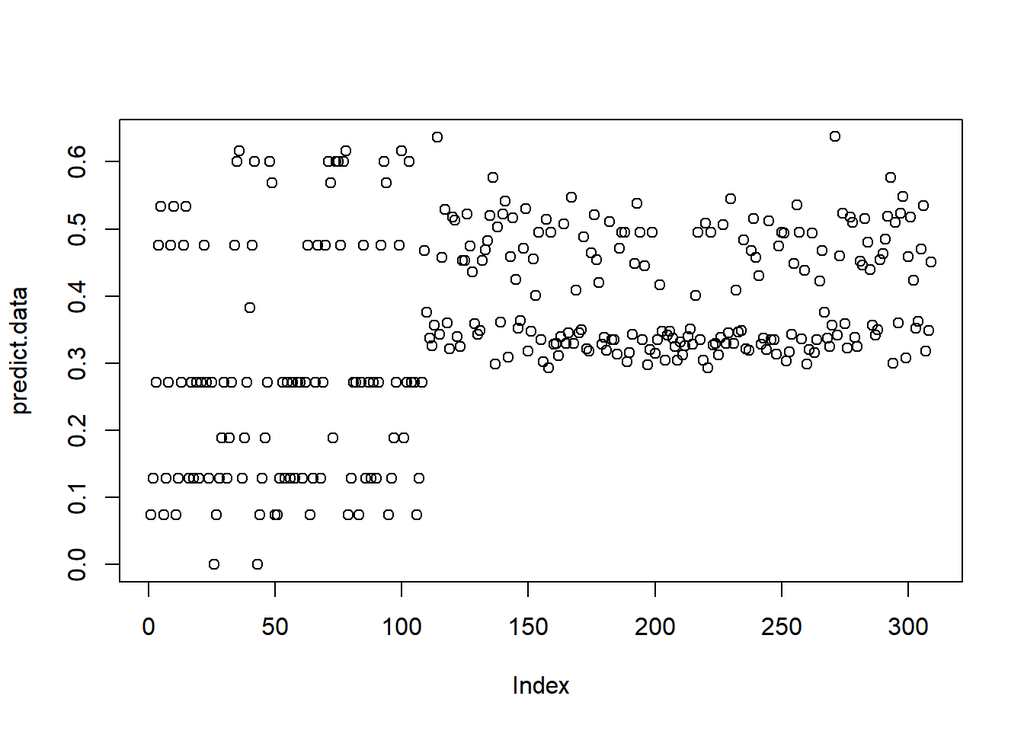

```r
#plot
plot(predict.data)
```

Análise boxplot, para visualizar se há outliers.

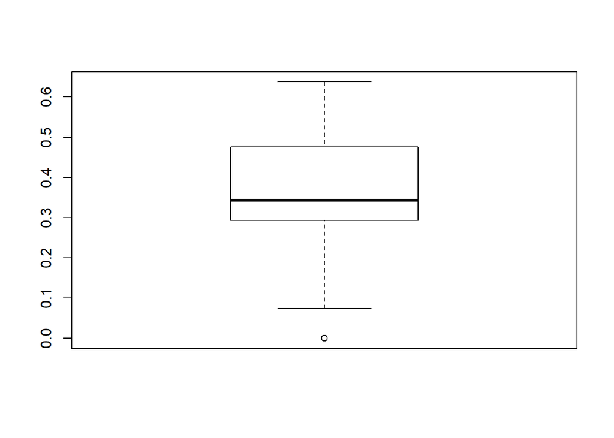

```r
# boxplot
boxplot(predict.data)
```

## Construindo predicted.csv

Construção do arquivo csv a ser submetido para averiguação na plataforma Kaggle.

```r
ID <- testingData[c("ID")]
result <- data.frame(ID,predict.data)
colnames(result) <- c('ID', 'strength')
write.table(result,file="predicted.csv",col.names = c('ID','strength'), row.names = FALSE,sep = ",", quote = FALSE)
result.data <- read.csv(file="predicted.csv", header=TRUE, sep=",")
```